# Investigating model weighting issues

Elliot Gould

May 27, 2024

```r
library(ManyEcoEvo)
library(tidyverse)
library(lme4)
```

# Exploring Model Weights

Create orchard-style plots for both BT and Euc, without removing analyses with extreme weights:

```
## We selected `at = c("PublishableAsIs")`.
## We selected `at = c("PublishableAsIs")`.
```

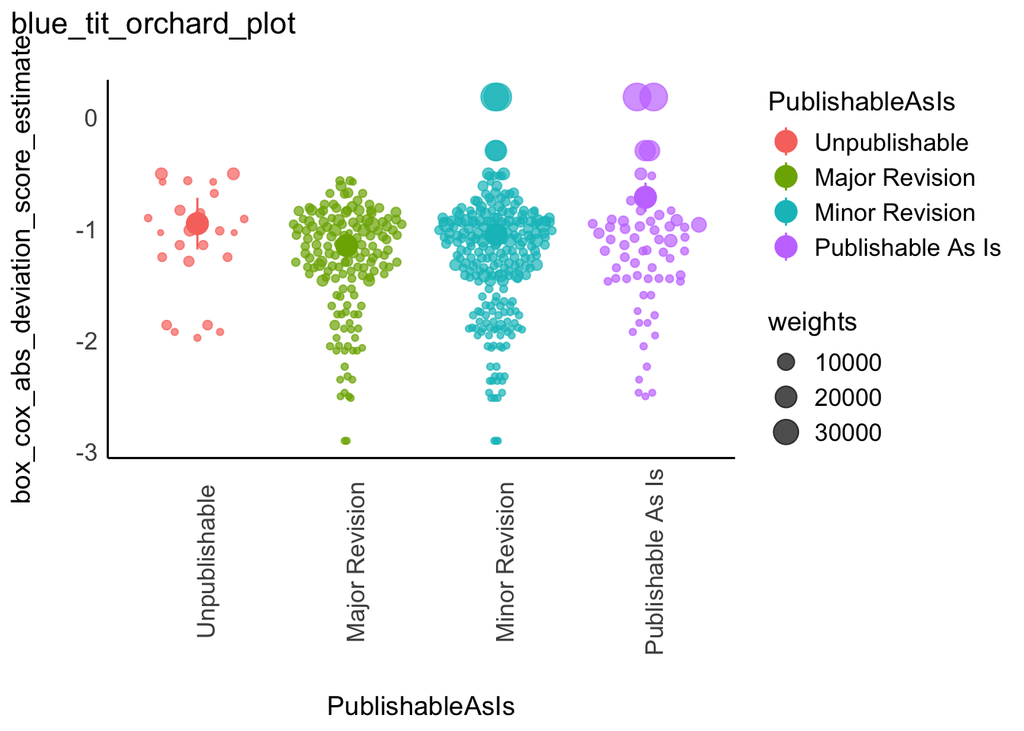

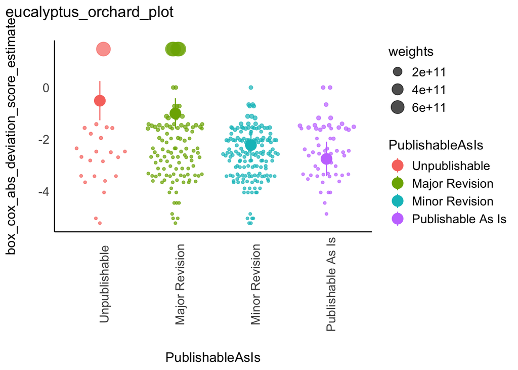

```r
ManyEcoEvo_results %>%
  ungroup %>%
  filter(exclusion_set == "complete",
         publishable_subset == "All",
         expertise_subset == "All") %>%
  hoist(.col = effects_analysis,
        "lambda",
        .simplify = TRUE,
        .transform = unique) %>%
  select(exclusion_set,
         dataset,
         estimate_type,
         box_cox_rating_cat,
         lambda) %>%
  mutate(predictor_means =
           map(box_cox_rating_cat, modelbased::estimate_means),
         model_data = map(box_cox_rating_cat, ~pluck(.x, "frame") %>%
                            drop_na() %>%
                            as_tibble()),
         plot_name = paste(exclusion_set, dataset, sep = ", ")) %>%
  mutate(model_data = map(model_data,
                          .f = ~ mutate(.x, PublishableAsIs =
                                          str_replace(PublishableAsIs,
                                                      "publishable with ", "") %>%
                                          str_replace("deeply flawed and ", "") %>%
                                          capwords())),
         predictor_means = map(predictor_means,
                               .f = ~ mutate(.x, PublishableAsIs =
                                               str_replace(PublishableAsIs,
                                                           "publishable with ", "") %>%
                                               str_replace("deeply flawed and ", "") %>%
                                               capwords()))) %>%
  mutate(plot_name =
           str_remove(plot_name, "complete, ") %>%
           str_replace_all(., " ", "_") %>%
           paste0("_orchard_plot")) %>%
  pmap(.l = list(.$model_data, .$predictor_means, .$plot_name),
       .f = ~ plot_model_means_orchard(..1,
                                       PublishableAsIs,
                                       ..2,
                                       new_order =
                                         c("Unpublishable",
                                           "Major Revision",
                                           "Minor Revision",
                                           "Publishable As Is"),
                                       ..3))
```

From the above it’s clear that the general pattern is for the higher weighted cases to pull the model means closer to them. In the case of the eucalyptus data, it’s several EXTREME weights that are pulling the model means closer to them. Let’s look at the distributions of weights and their values for the euc dataset Weight Distribution Blue Tit Model:

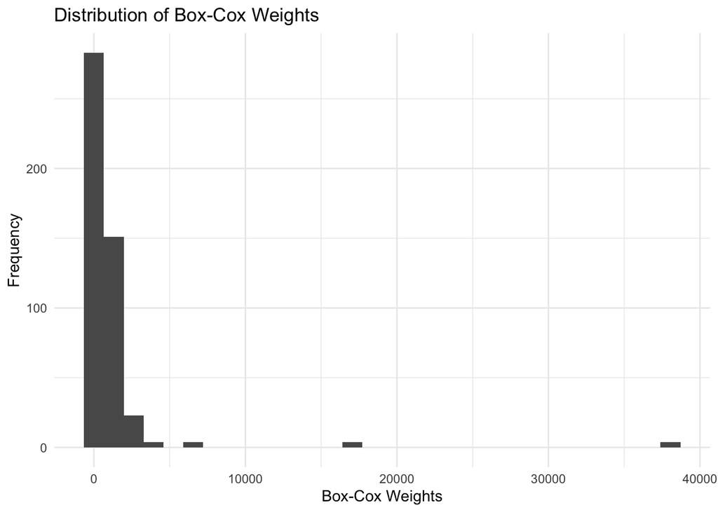

```r
ManyEcoEvo_results %>%
  ungroup %>%
  filter(exclusion_set == "complete",
         publishable_subset == "All",
         expertise_subset == "All",
         dataset == "blue tit") %>%
  hoist(.col = effects_analysis,
        "lambda",
        .simplify = TRUE,
        .transform = unique) %>%
  select(exclusion_set,
         dataset,
         estimate_type,
         box_cox_rating_cat,
         lambda, data) %>% pull(box_cox_rating_cat) %>%
  pluck(1) %>%
  model.frame() %>%
  as_tibble() %>%
  rename(weights = `(weights)`) %>%
  mutate(weights = as.numeric(weights)) %>%
  ggplot(aes(x = weights)) +
  geom_histogram(bins = 30) +
  labs(title = "Distribution of Box-Cox Weights",
       x = "Box-Cox Weights",
       y = "Frequency") +
  theme_minimal() +
  theme(legend.position = "none")
```

Weight Distribution Eucalyptus Model

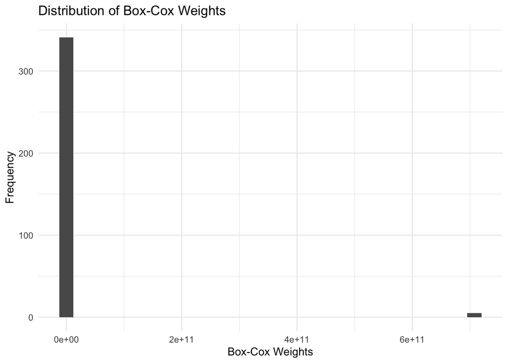

```r
ManyEcoEvo_results %>%
  ungroup %>%
  filter(exclusion_set == "complete",
         publishable_subset == "All",
         expertise_subset == "All",
         dataset == "eucalyptus") %>%
  hoist(.col = effects_analysis,
        "lambda",
        .simplify = TRUE,
        .transform = unique) %>%
  select(exclusion_set,
         dataset,
         estimate_type,
         box_cox_rating_cat,
         lambda, data) %>%
  pull(box_cox_rating_cat) %>%
  pluck(1) %>%
  model.frame() %>%
  as_tibble() %>%
  rename(weights = `(weights)`) %>%
  mutate(weights = as.numeric(weights)) %>%
  ggplot(aes(x = weights)) +
  geom_histogram(bins = 30) +
  labs(title = "Distribution of Box-Cox Weights",
       x = "Box-Cox Weights",
       y = "Frequency") +
  theme_minimal() +
  theme(legend.position = "none")
```

Weight Distribution for Eucalyptus model when case with maximum weight removed

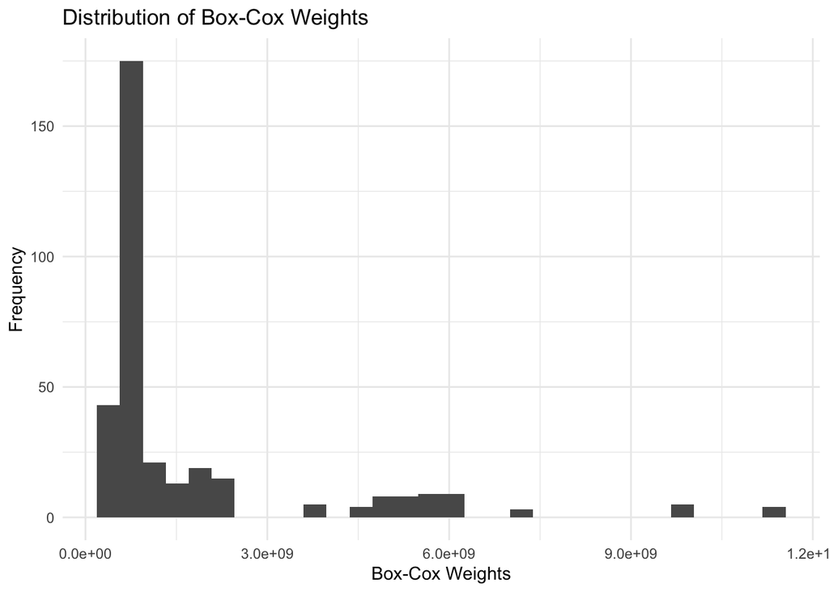

```r
ManyEcoEvo_results %>%
  ungroup %>%
  filter(exclusion_set == "complete",
         publishable_subset == "All",
         expertise_subset == "All",
         dataset == "eucalyptus") %>%
  hoist(.col = effects_analysis,
        "lambda",
        .simplify = TRUE,
        .transform = unique) %>%
  select(exclusion_set,
         dataset,
         estimate_type,
         box_cox_rating_cat,
         lambda, data) %>%
  pull(box_cox_rating_cat) %>%
  pluck(1) %>%
  model.frame() %>%
  as_tibble() %>%
  rename(weights = `(weights)`) %>%
  mutate(weights = as.numeric(weights)) %>%
  filter(weights != max(weights)) %>%
  ggplot(aes(x = weights)) +
  geom_histogram(bins = 30) +
  labs(title = "Distribution of Box-Cox Weights",
       x = "Box-Cox Weights",
       y = "Frequency") +
  theme_minimal() +
  theme(legend.position = "none")
```

Let’s see all values of weight

```r
ManyEcoEvo_results %>%
  ungroup %>%
  filter(exclusion_set == "complete",
         publishable_subset == "All",
         expertise_subset == "All",
         dataset == "eucalyptus") %>%
  hoist(.col = effects_analysis,
        "lambda",
        .simplify = TRUE,
        .transform = unique) %>%
  select(exclusion_set,
         dataset,
         estimate_type,
         box_cox_rating_cat,
         lambda, data) %>%
  pull(box_cox_rating_cat) %>%
  pluck(1) %>%
  model.frame() %>%
  as_tibble() %>%
  rename(weights = `(weights)`) %>%
  mutate(weights = as.numeric(weights)) %>%
  pluck("weights", unique, sort) # all weights
```

```
##  [1]    563686395    563717442    563749404    563792386    565399621
##  [6]    565829955    565935996    566268848    567997367    569333108
## [11]    574528639    575196234    575387867    575722251    577600776
## [16]    579285551    579948308    580899020    583278546    584152556
## [21]    585498693    588256091    589433325    591917249    592900308
## [26]    607544276    617833974    622796581    626556210    633218858
## [31]    634782083    639555963    645135519    675024708    679607659
## [36]    679917410    685839966    694551570    731532604    810363823
## [41]    841303906    848538448    872489778    883906458    889910295
## [46]    890972369    919288483    933683584    962902173   1041096068
## [51]   1105126672   1155109828   1175856985   1373998220   1553121885
## [56]   1652915383   1739127212   1859021802   1921555550   1932590106
## [61]   2160580342   2185971274   2284404564   3627724910   4623841569
## [66]   5082015565   5099533477   5127083966   5313360448   5637576773
## [71]   5749335304   5767498603   5986636683   6027266130   7006392797
## [76]   9979626599  11545920175 708161001050
```

What are the cases with extreme weights? Below we identify the cases with the top 2 maximum weights

```r
extreme_weight_observation <-
  ManyEcoEvo_results %>%
  ungroup %>%
  filter(exclusion_set == "complete",
         publishable_subset == "All",
         expertise_subset == "All",
         dataset == "eucalyptus") %>%
  pluck("effects_analysis", 1) %>%
  select(study_id, box_cox_abs_deviation_score_estimate, box_cox_var) %>%
  mutate(weights = 1/box_cox_var) %>%
  # filter(weights == max(weights))
  filter(weights > 10000000000)
extreme_weight_observation
```

```
## # A tibble: 2 × 4
##   study_id       box_cox_abs_deviation_score_estimate box_cox_var       weights
##   <chr>                                         <dbl>       <dbl>         <dbl>
## 1 Brooklyn-2-2-1                                 1.48    1.41e-12 708161001050.
## 2 Cassilis-1-1-1                                -1.11    8.66e-11  11545920175.
```

# Investigating the impact of extreme weights by removing them

Remove cases with extreme weights and refit / plot models

```r
refitted_eucalyptus_model <-
  ManyEcoEvo_results %>%
  ungroup %>%
  filter(exclusion_set == "complete",
         publishable_subset == "All",
         expertise_subset == "All",
         dataset == "eucalyptus") %>%
  mutate(effects_analysis = map(effects_analysis, ~filter(.x, study_id %nin% extreme_weight_observation$study_id))) %>%
  mutate(box_cox_rating_cat = map(effects_analysis, ~fit_boxcox_ratings_cat(
    .data = .x,
    outcome = box_cox_abs_deviation_score_estimate,
    outcome_var = box_cox_var,
    interceptless = FALSE
  )))
```

```
## ── Fitting lmer with categorical ratings predictor on box_cox_transformed outcomes ──
```

```
## boundary (singular) fit: see help('isSingular')
```

Note, not shown here yet. But when only the top most case is removed, lme4 gives singular fit warning, when I run check_singularity() on the model, it seems OK. When the top two cases are removed, singular fit warning is given by lme4, and check_singularity() returns FALSE, meaning the model is singular. Also, when I check convergence on the model with top 2 cases removed, gradient shifts from ~3.79e^-5 with only case with max weight removed to 0. Seems strange to me that this would occur when both extreme weights are removed… Anyways, I progress with refitting and plotting after removing cases with weights 10000000000 and above (here, there are two). Recreate the plot data for regenerating plots after refitting models

```r
refitted_plot_data<-
  refitted_eucalyptus_model %>%
  hoist(.col = effects_analysis,
        "lambda",
        .simplify = TRUE,
        .transform = unique) %>%
  select(exclusion_set,
         dataset,
         estimate_type,
         box_cox_rating_cat,
         lambda) %>%
  mutate(predictor_means =
           map(box_cox_rating_cat, modelbased::estimate_means),
         model_data = map(box_cox_rating_cat, ~pluck(.x, "frame") %>%
                            drop_na() %>%
                            as_tibble()),
         plot_name = paste(exclusion_set, dataset, sep = ", ")) %>%
  mutate(model_data = map(model_data,
                          .f = ~ mutate(.x, PublishableAsIs =
                                          str_replace(PublishableAsIs,
                                                      "publishable with ", "") %>%
                                          str_replace("deeply flawed and ", "") %>%
                                          capwords())),
         predictor_means = map(predictor_means,
                               .f = ~ mutate(.x, PublishableAsIs =
                                               str_replace(PublishableAsIs,
                                                           "publishable with ", "") %>%
                                               str_replace("deeply flawed and ", "") %>%
                                               capwords()))) %>%
  mutate(plot_name =
           str_remove(plot_name, "complete, ") %>%
           str_replace_all(., " ", "_") %>%
           paste0("_violin_plot"))
```

```
## We selected `at = c("PublishableAsIs")`.
```

Create violin plots for refitted models

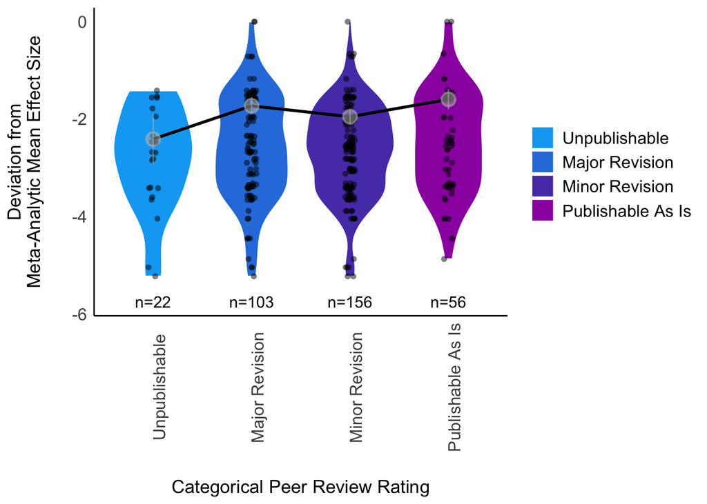

```r
refitted_plot_data %>%
  pmap(.l = list(.$model_data, .$predictor_means, .$plot_name, .$lambda),
       .f = ~ plot_model_means_box_cox_cat(..1,
                                           PublishableAsIs,
                                           ..2,
                                           new_order =
                                             c("Unpublishable",
                                               "Major Revision",
                                               "Minor Revision",
                                               "Publishable As Is"),
                                           ..3, ..4, back_transform = FALSE))
```

Regenerate plot but back-transform to original scale (absolute deviation from meta-analytic mean)

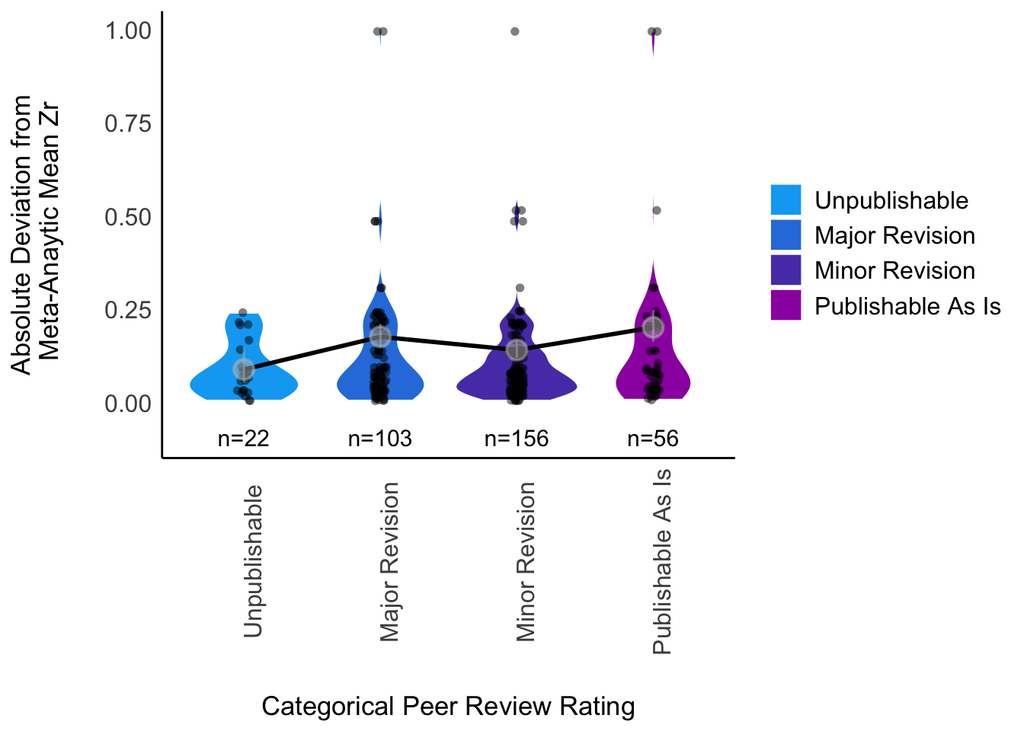

```r
refitted_plot_data %>%
  pmap(.l = list(.$model_data, .$predictor_means, .$plot_name, .$lambda),
        .f = ~ plot_model_means_box_cox_cat(..1,
                                            PublishableAsIs,
                                            ..2,
                                            new_order =
                                              c("Unpublishable",
                                                "Major Revision",
                                                "Minor Revision",
                                                "Publishable As Is"),
                                            ..3, ..4, back_transform = TRUE))
```

Create orchard-style plots for refitted models

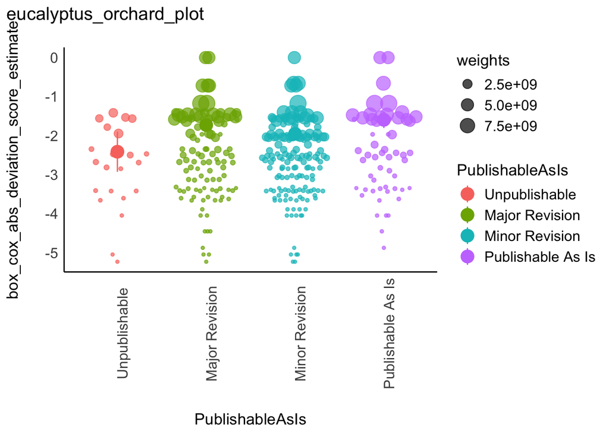

```r
refitted_plot_data %>%
  mutate(plot_name = str_replace(plot_name, "_violin_plot", "_orchard_plot")) %>%
  pmap(.l = list(.$model_data, .$predictor_means, .$plot_name),
       .f = ~ plot_model_means_orchard(..1,
                                           PublishableAsIs,
                                           ..2,
                                           new_order =
                                             c("Unpublishable",
                                               "Major Revision",
                                               "Minor Revision",
                                               "Publishable As Is"),
                                           ..3))
```

What is causing these extreme values observed in `extreme_weight_observation`? Is the weight calculation ok?

```r
ManyEcoEvo_results %>%
  ungroup %>%
  filter(exclusion_set == "complete",
         publishable_subset == "All",
         expertise_subset == "All",
         dataset == "eucalyptus") %>%
  select(effects_analysis) %>%
  unnest(effects_analysis) %>%
  filter(study_id %in% extreme_weight_observation$study_id) %>%
  select(study_id,
         Zr,
         VZr,
         abs_deviation_score_estimate,
         box_cox_abs_deviation_score_estimate,
         folded_mu_val,
         folded_v_val,
         box_cox_var,
         lambda) %>%
  mutate(weights = 1/box_cox_var)
```

```
## # A tibble: 2 × 10
##   study_id           Zr     VZr abs_deviation_score_est…¹ box_cox_abs_deviatio…²
##   <chr>           <dbl>   <dbl>                     <dbl>                  <dbl>
## 1 Brooklyn-2-2-1 -4.47  0.00870                     4.38                    1.48
## 2 Cassilis-1-1-1  0.236 0.00300                     0.328                  -1.11
## # ℹ abbreviated names: ¹abs_deviation_score_estimate,
## #   ²box_cox_abs_deviation_score_estimate
## # ℹ 5 more variables: folded_mu_val <dbl>, folded_v_val <dbl>,
## #   box_cox_var <dbl>, lambda <dbl>, weights <dbl>
```

```r
ManyEcoEvo_results %>%
  ungroup %>%
  filter(exclusion_set == "complete",
         publishable_subset == "All",
         expertise_subset == "All") %>%
  select(effects_analysis) %>%
  unnest(effects_analysis) %>%
  unnest(review_data) %>%
  mutate(weights = 1/box_cox_var) %>%
  write_csv("extreme_weight_analysis_info.csv")
```

The `weights` are calculated as the inverse of the variance of the box-cox transformed absolute deviation scores. The variance of the box-cox transformed absolute deviation scores `box_cox_var` is calculated as the variance of the folded absolute deviation scores and the folded variance of the absolute deviation scores The folded absolute deviation scores `folded_mu` and the The folded variance of the absolute deviation scores `folded_v` are calculated as follows:

```r
box_cox_transform
```

```
## function(data, dataset) {
##   if(rlang::is_na(data) | rlang::is_null(data)){
##     cli::cli_alert_warning(text =  glue::glue("Cannot box-cox transform data for",
##                                               paste(names(dplyr::cur_group()),
##                                                     dplyr::cur_group(),
##                                                     sep = " = ",
##                                                     collapse = ", ")))
##     result <- NA
##   } else{
##     cli::cli_h2(glue::glue("Box-cox transforming absolute deviation scores for ", {dataset}))
##
##     box_cox_recipe <- recipes::recipe(~.,
##                                       data = select(data,
##                                                     starts_with("abs_deviation_score_"))) %>%
##       timetk::step_box_cox(everything(),limits = c(0,10)) %>%
##       recipes::prep(training = data, retain = TRUE) #estimate lambda + box cox transform vars
##
##     if(box_cox_recipe %>%
##        recipes::tidy(number = 1) %>% nrow() > 0){
##       lambda <- box_cox_recipe %>%
##         recipes::tidy(number = 1) %>%
##         pull(., lambda) %>%
##         `names<-`(., pull(box_cox_recipe %>%
##                             recipes::tidy(number = 1), terms))
##
##       if(!is.null(dataset)){
##         cli::cli_alert_info(c(
##           "Optimised Lambda used in Box-Cox Transformation of ",
##           "{dataset} dataset variables ",
##           "is {round(lambda, 4)} for `{names(lambda)}`."
##         ))
##       }
##
##       variance_box_cox <- function(folded_mu, folded_v, lambda){
##         variance_bc <- folded_v*(lambda*folded_mu^(lambda-1))^2 # delta method
##         return(variance_bc)
##       }
##
##       # folded abs_dev_score
##       folded_mu <- function(abs_dev_score, VZr) {
```

[output cut: 25 more lines]

```
##                lambda = lambda[[1]])
##
##     } else{
##       result <- NA
##       cli::cli_alert_warning(text =  glue::glue("Lambda cannot be computed."))
##     }
##
##
##   }
##
##   return(result)
##
## }
## <bytecode: 0x1518aed10>
## <environment: namespace:ManyEcoEvo>
```

# Try using folded_v instead of box_cox_var to calculate weights

```r
refitted_eucalyptus_model_folded_v <-
  ManyEcoEvo_results %>%
  ungroup %>%
  filter(exclusion_set == "complete",
         publishable_subset == "All",
         expertise_subset == "All",
         dataset == "eucalyptus") %>%
  mutate(box_cox_rating_cat = map(effects_analysis, ~fit_boxcox_ratings_cat(
    .data = .x,
    outcome = box_cox_abs_deviation_score_estimate,
    outcome_var = folded_v_val,
    interceptless = FALSE
  )))
```

```
## ── Fitting lmer with categorical ratings predictor on box_cox_transformed outcomes ──
```

```r
refitted_plot_data_folded_v <-
  refitted_eucalyptus_model_folded_v %>%
  hoist(.col = effects_analysis,
        "lambda",
        .simplify = TRUE,
        .transform = unique) %>%
  select(exclusion_set,
         dataset,
         estimate_type,
         box_cox_rating_cat,
         lambda) %>%
  mutate(predictor_means =
           map(box_cox_rating_cat, modelbased::estimate_means),
         model_data = map(box_cox_rating_cat, ~pluck(.x, "frame") %>%
                            drop_na() %>%
                            as_tibble()),
         plot_name = paste(exclusion_set, dataset, sep = ", ")) %>%
  mutate(model_data = map(model_data,
                          .f = ~ mutate(.x, PublishableAsIs =
                                          str_replace(PublishableAsIs,
                                                      "publishable with ", "") %>%
                                          str_replace("deeply flawed and ", "") %>%
                                          capwords())),
         predictor_means = map(predictor_means,
                               .f = ~ mutate(.x, PublishableAsIs =
                                               str_replace(PublishableAsIs,
                                                           "publishable with ", "") %>%
                                               str_replace("deeply flawed and ", "") %>%
                                               capwords()))) %>%
  mutate(plot_name =
           str_remove(plot_name, "complete, ") %>%
           str_replace_all(., " ", "_") %>%
           paste0("_violin_plot"))
```

```
## We selected `at = c("PublishableAsIs")`.
```

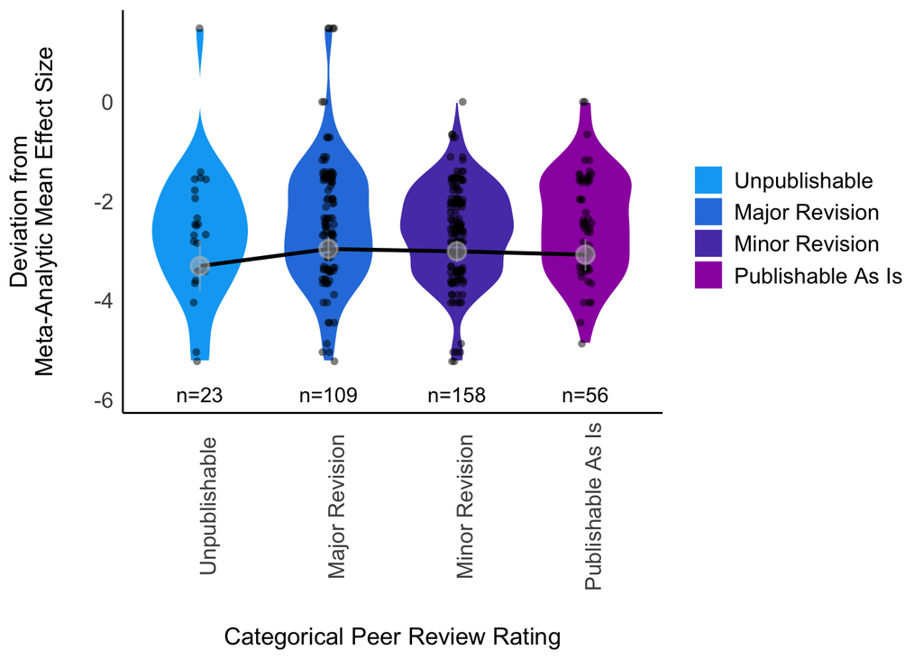

```r
refitted_plot_data_folded_v %>%
  pmap(.l = list(.$model_data, .$predictor_means, .$plot_name, .$lambda),
       .f = ~ plot_model_means_box_cox_cat(..1,
                                           PublishableAsIs,
                                           ..2,
                                           new_order =
                                             c("Unpublishable",
                                               "Major Revision",
                                               "Minor Revision",
                                               "Publishable As Is"),
                                           ..3, ..4, back_transform = FALSE))
```